# Predicting Book Ratings

Eric Zhong

## Introduction

Books are one of the oldest forms of entertainment that have accompanied humans throughout the ages. It is also one of the best ways to throughly transmit ideas, discussions, cultures, and even morality. However, in todays world where attention is one of the greatest commodities, it's harder than ever before to get someone's attention and make them want to read what you wrote. Advancing recommender systems, review aggregator sites, ads, as well as best seller lists are all ways to get attention on a piece of writing. In this tutorial, I'll be looking into how an audiences perception of a book's genre is related to how well it's rated.

The data being used here is downloaded from https://www.kaggle.com/datasets/tanguypledel/science-fiction-books-subgenres. The data is about science fiction books from goodreads.com

## Getting the Data

We start by importing important libraries as well as loading up the data. We are using pandas since the dataframe structure has some great functionality when it comes to data manipulation, cleaning, analysis, and model training. The data is separated by different subgenre's of science fiction such as aliens, alternate history, etc. We'll add all of those to an array so we can loop over them rather than repeating code for each separate dataframe.

```python
import pandas as pd
import numpy as np
import matplotlib.pyplot as plt
import seaborn as sns
from sklearn import model_selection
from sklearn import linear_model
from sklearn.tree import DecisionTreeClassifier
from sklearn.tree import DecisionTreeRegressor
import ast

dataset = {}
alien_df = pd.read_csv('sf_aliens.csv')
history_df = pd.read_csv('sf_alternate_history.csv')
universe_df = pd.read_csv('sf_alternate_universe.csv')
apocalyptic_df = pd.read_csv('sf_apocalyptic.csv')
cyberpunk_df = pd.read_csv('sf_cyberpunk.csv')
dystopia_df = pd.read_csv('sf_dystopia.csv')
hard_df = pd.read_csv('sf_hard.csv')
military_df = pd.read_csv('sf_military.csv')
robot_df = pd.read_csv('sf_robots.csv')
space_df = pd.read_csv('sf_space_opera.csv')
steampunk_df = pd.read_csv('sf_steampunk.csv')
time_df = pd.read_csv('sf_time_travel.csv')

dataset['alien'] = alien_df
dataset['history'] = history_df
dataset['universe'] = universe_df
dataset['apocalyptic'] = apocalyptic_df
dataset['cyberpunk'] = cyberpunk_df
dataset['dystopia'] = dystopia_df
dataset['hard'] = hard_df
dataset['military'] = military_df
dataset['robot'] = robot_df
dataset['space'] = space_df
dataset['steampunk'] = steampunk_df
dataset['time'] = time_df

dataset['alien'].head()
```

|  | Book_Title | Original_Book_Title | Author_Name | Edition_Language | Rating_score | Rating_votes | Review_number | Book_Description | Year_published | Genres | url |
| --- | --- | --- | --- | --- | --- | --- | --- | --- | --- | --- | --- |
| 0 | Obsidian | Obsidian | Jennifer L. Armentrout | English | 4.17 | 236780 | 18161 | Starting over sucks.When we moved to West Virg... | 2011 | {'Young Adult': 3439, 'Fantasy (Paranormal) ':... | https://www.goodreads.com/book/show/12578077-o... |
| 1 | Onyx | Onyx | Jennifer L. Armentrout | English | 4.27 | 153429 | 10497 | BEING CONNECTED TO DAEMON BLACK SUCKS… Thanks ... | 2012 | {'Young Adult': 2271, 'Fantasy (Paranormal) ':... | https://www.goodreads.com/book/show/13047090-onyx |
| 2 | The 5th Wave | The 5th Wave | Rick Yancey | English | 4.03 | 400600 | 29990 | After the 1st wave, only darkness remains. Aft... | 2013 | {'Young Adult': 5436, 'Science Fiction': 3327,... | https://www.goodreads.com/book/show/16101128-t... |
| 3 | The Host | The Host | Stephenie Meyer | English | 3.84 | 915026 | 41673 | Melanie Stryder refuses to fade away. The eart... | 2008 | {'Young Adult': 4529, 'Science Fiction': 4285,... | https://www.goodreads.com/book/show/1656001.Th... |
| 4 | Opal | Opal | Jennifer L. Armentrout | None | 4.27 | 129006 | 9463 | No one is like Daemon Black.When he set out to... | 2012 | {'Young Adult': 1855, 'Fantasy (Paranormal) ':... | https://www.goodreads.com/book/show/13362536-opal |

Looking at what the csv files contain, we see

- book title
- author
- language
- rating
- votes
- number of reviews
- summary of the book
- year published
- dictionary holding user votes of what genre they think the book belongs to

Next, we'll take a look at how many books there are before and after we remove rows with missing values.

```python
dataset['alien'].shape
```

```
(1250, 11)
```

```python
for key in dataset:
    dataset[key].dropna(axis=0, inplace=True)
dataset['alien'].shape
```

```
(1249, 11)
```

With our sample dataset 'alien', we see that there aren't that many rows with missing values. In fact, you can go to the kaggle website mentioned above and look at each csv file with the column format to see which columns are missing values.

## Cleaning the Data

Let's start cleaning up our data by dropping some unnecessary columns. 'Original Book Title' seems redundant for now and I don't intend to go back and manually scrap from goodreads so we'll drop those.

```python
for key in dataset:
    dataset[key].drop('Original_Book_Title', axis=1, inplace=True)
    dataset[key].drop('url', axis=1, inplace=True)
dataset['alien'].head()
```

|  | Book_Title | Author_Name | Edition_Language | Rating_score | Rating_votes | Review_number | Book_Description | Year_published | Genres |
| --- | --- | --- | --- | --- | --- | --- | --- | --- | --- |
| 0 | Obsidian | Jennifer L. Armentrout | English | 4.17 | 236780 | 18161 | Starting over sucks.When we moved to West Virg... | 2011 | {'Young Adult': 3439, 'Fantasy (Paranormal) ':... |
| 1 | Onyx | Jennifer L. Armentrout | English | 4.27 | 153429 | 10497 | BEING CONNECTED TO DAEMON BLACK SUCKS… Thanks ... | 2012 | {'Young Adult': 2271, 'Fantasy (Paranormal) ':... |
| 2 | The 5th Wave | Rick Yancey | English | 4.03 | 400600 | 29990 | After the 1st wave, only darkness remains. Aft... | 2013 | {'Young Adult': 5436, 'Science Fiction': 3327,... |
| 3 | The Host | Stephenie Meyer | English | 3.84 | 915026 | 41673 | Melanie Stryder refuses to fade away. The eart... | 2008 | {'Young Adult': 4529, 'Science Fiction': 4285,... |
| 4 | Opal | Jennifer L. Armentrout | None | 4.27 | 129006 | 9463 | No one is like Daemon Black.When he set out to... | 2012 | {'Young Adult': 1855, 'Fantasy (Paranormal) ':... |

It turns out that the dictionaries in the 'Genres' are actually strings! Let's fix that by applying the ast.literal_eval function to convert the strings into dictionaries.

```python
for key in dataset:
    dataset[key]['Genres'] = dataset[key]['Genres'].apply(ast.literal_eval)
```

Next, we'll convert the dictionaries into a dataframe using the pd.Series function and concatenate with our original dataset. This should create a sparse matrix with how many genres there are.

```python
for key in dataset:
    dataset[key] = pd.concat([dataset[key], dataset[key]['Genres'].apply(pd.Series)], axis=1)
dataset['alien'].head()
```

|  | Book_Title | Author_Name | Edition_Language | Rating_score | Rating_votes | Review_number | Book_Description | Year_published | Genres | Young Adult | ... | Paranormal (Angels) | Fantasy (Unicorns) | Historical (Medieval) | Manga (Seinen) | Comics Manga | The United States Of America | Science Fiction (Cyberpunk) | Science (Mathematics) | Romance (Love Story) | Humanities (Linguistics) |
| --- | --- | --- | --- | --- | --- | --- | --- | --- | --- | --- | --- | --- | --- | --- | --- | --- | --- | --- | --- | --- | --- |
| 0 | Obsidian | Jennifer L. Armentrout | English | 4.17 | 236780 | 18161 | Starting over sucks.When we moved to West Virg... | 2011 | {'Young Adult': 3439, 'Fantasy (Paranormal) ':... | 3439.0 | ... | NaN | NaN | NaN | NaN | NaN | NaN | NaN | NaN | NaN | NaN |
| 1 | Onyx | Jennifer L. Armentrout | English | 4.27 | 153429 | 10497 | BEING CONNECTED TO DAEMON BLACK SUCKS… Thanks ... | 2012 | {'Young Adult': 2271, 'Fantasy (Paranormal) ':... | 2271.0 | ... | NaN | NaN | NaN | NaN | NaN | NaN | NaN | NaN | NaN | NaN |
| 2 | The 5th Wave | Rick Yancey | English | 4.03 | 400600 | 29990 | After the 1st wave, only darkness remains. Aft... | 2013 | {'Young Adult': 5436, 'Science Fiction': 3327,... | 5436.0 | ... | NaN | NaN | NaN | NaN | NaN | NaN | NaN | NaN | NaN | NaN |
| 3 | The Host | Stephenie Meyer | English | 3.84 | 915026 | 41673 | Melanie Stryder refuses to fade away. The eart... | 2008 | {'Young Adult': 4529, 'Science Fiction': 4285,... | 4529.0 | ... | NaN | NaN | NaN | NaN | NaN | NaN | NaN | NaN | NaN | NaN |
| 4 | Opal | Jennifer L. Armentrout | None | 4.27 | 129006 | 9463 | No one is like Daemon Black.When he set out to... | 2012 | {'Young Adult': 1855, 'Fantasy (Paranormal) ':... | 1855.0 | ... | NaN | NaN | NaN | NaN | NaN | NaN | NaN | NaN | NaN | NaN |

5 rows × 205 columns

We ended up adding 196 extra columns! Let's get rid of the Not A Number(NaN) entries left over from the conversion from dict to dataframe using fillna().

```python
for key in dataset:
    dataset[key] = dataset[key].fillna(0)
dataset['alien'].head()
```

|  | Book_Title | Author_Name | Edition_Language | Rating_score | Rating_votes | Review_number | Book_Description | Year_published | Genres | Young Adult | ... | Paranormal (Angels) | Fantasy (Unicorns) | Historical (Medieval) | Manga (Seinen) | Comics Manga | The United States Of America | Science Fiction (Cyberpunk) | Science (Mathematics) | Romance (Love Story) | Humanities (Linguistics) |
| --- | --- | --- | --- | --- | --- | --- | --- | --- | --- | --- | --- | --- | --- | --- | --- | --- | --- | --- | --- | --- | --- |
| 0 | Obsidian | Jennifer L. Armentrout | English | 4.17 | 236780 | 18161 | Starting over sucks.When we moved to West Virg... | 2011 | {'Young Adult': 3439, 'Fantasy (Paranormal) ':... | 3439.0 | ... | 0.0 | 0.0 | 0.0 | 0.0 | 0.0 | 0.0 | 0.0 | 0.0 | 0.0 | 0.0 |
| 1 | Onyx | Jennifer L. Armentrout | English | 4.27 | 153429 | 10497 | BEING CONNECTED TO DAEMON BLACK SUCKS… Thanks ... | 2012 | {'Young Adult': 2271, 'Fantasy (Paranormal) ':... | 2271.0 | ... | 0.0 | 0.0 | 0.0 | 0.0 | 0.0 | 0.0 | 0.0 | 0.0 | 0.0 | 0.0 |
| 2 | The 5th Wave | Rick Yancey | English | 4.03 | 400600 | 29990 | After the 1st wave, only darkness remains. Aft... | 2013 | {'Young Adult': 5436, 'Science Fiction': 3327,... | 5436.0 | ... | 0.0 | 0.0 | 0.0 | 0.0 | 0.0 | 0.0 | 0.0 | 0.0 | 0.0 | 0.0 |
| 3 | The Host | Stephenie Meyer | English | 3.84 | 915026 | 41673 | Melanie Stryder refuses to fade away. The eart... | 2008 | {'Young Adult': 4529, 'Science Fiction': 4285,... | 4529.0 | ... | 0.0 | 0.0 | 0.0 | 0.0 | 0.0 | 0.0 | 0.0 | 0.0 | 0.0 | 0.0 |
| 4 | Opal | Jennifer L. Armentrout | None | 4.27 | 129006 | 9463 | No one is like Daemon Black.When he set out to... | 2012 | {'Young Adult': 1855, 'Fantasy (Paranormal) ':... | 1855.0 | ... | 0.0 | 0.0 | 0.0 | 0.0 | 0.0 | 0.0 | 0.0 | 0.0 | 0.0 | 0.0 |

5 rows × 205 columns

Now we can drop the original genres as well as other columns that we don't need for our analysis.

```python
for key in dataset:
    dataset[key].drop('Genres', axis=1, inplace=True)
dataset['alien'].shape
```

```
(1249, 204)
```

```python
for key in dataset:
    dataset[key].drop('Book_Title', axis=1, inplace=True)
    dataset[key].drop('Author_Name', axis=1, inplace=True)
    dataset[key].drop('Edition_Language', axis=1, inplace=True)
    dataset[key].drop('Book_Description', axis=1, inplace=True)
    dataset[key].drop('Year_published', axis=1, inplace=True)
dataset['alien'].shape
```

```
(1249, 199)
```

```python
dataset['alien'].head()
```

|  | Rating_score | Rating_votes | Review_number | Young Adult | Fantasy (Paranormal) | Fantasy | Romance | Science Fiction (Aliens) | Science Fiction | Romance (Paranormal Romance) | ... | Paranormal (Angels) | Fantasy (Unicorns) | Historical (Medieval) | Manga (Seinen) | Comics Manga | The United States Of America | Science Fiction (Cyberpunk) | Science (Mathematics) | Romance (Love Story) | Humanities (Linguistics) |
| --- | --- | --- | --- | --- | --- | --- | --- | --- | --- | --- | --- | --- | --- | --- | --- | --- | --- | --- | --- | --- | --- |
| 0 | 4.17 | 236780 | 18161 | 3439.0 | 2652.0 | 2545.0 | 2507.0 | 1648.0 | 1170.0 | 849.0 | ... | 0.0 | 0.0 | 0.0 | 0.0 | 0.0 | 0.0 | 0.0 | 0.0 | 0.0 | 0.0 |
| 1 | 4.27 | 153429 | 10497 | 2271.0 | 1819.0 | 1595.0 | 1670.0 | 1304.0 | 775.0 | 595.0 | ... | 0.0 | 0.0 | 0.0 | 0.0 | 0.0 | 0.0 | 0.0 | 0.0 | 0.0 | 0.0 |
| 2 | 4.03 | 400600 | 29990 | 5436.0 | 0.0 | 1043.0 | 855.0 | 1225.0 | 3327.0 | 0.0 | ... | 0.0 | 0.0 | 0.0 | 0.0 | 0.0 | 0.0 | 0.0 | 0.0 | 0.0 | 0.0 |
| 3 | 3.84 | 915026 | 41673 | 4529.0 | 1316.0 | 4189.0 | 3110.0 | 1113.0 | 4285.0 | 449.0 | ... | 0.0 | 0.0 | 0.0 | 0.0 | 0.0 | 0.0 | 0.0 | 0.0 | 0.0 | 0.0 |
| 4 | 4.27 | 129006 | 9463 | 1855.0 | 1535.0 | 1288.0 | 1376.0 | 1101.0 | 656.0 | 507.0 | ... | 0.0 | 0.0 | 0.0 | 0.0 | 0.0 | 0.0 | 0.0 | 0.0 | 0.0 | 0.0 |

5 rows × 199 columns

Without those pesky words, we can begin normalizing the data.

We'll start by summing up the total number of votes for each genre and divide each genre column so we have a proportion rather than total number of people who voted for each genre.

We can also normalize Rating_votes and Review_number by subtracting the mean and dividing the difference by the standard deviation.

```python
for key in dataset:
    dataset[key]['Total_genre_vote'] = dataset[key].iloc[:,3:].sum(axis=1)
    dataset[key].iloc[:,3:] = dataset[key].iloc[:,3:].div(dataset[key].Total_genre_vote, axis=0)
    dataset[key]['Rating_votes']=(dataset[key]['Rating_votes']-dataset[key]['Rating_votes'].mean())/dataset[key]['Rating_votes'].std()
    dataset[key]['Review_number']=(dataset[key]['Review_number']-dataset[key]['Review_number'].mean())/dataset[key]['Review_number'].std()
    dataset[key].drop('Total_genre_vote', axis=1, inplace=True)
```

```python
dataset['alien'].head()
```

|  | Rating_score | Rating_votes | Review_number | Young Adult | Fantasy (Paranormal) | Fantasy | Romance | Science Fiction (Aliens) | Science Fiction | Romance (Paranormal Romance) | ... | Paranormal (Angels) | Fantasy (Unicorns) | Historical (Medieval) | Manga (Seinen) | Comics Manga | The United States Of America | Science Fiction (Cyberpunk) | Science (Mathematics) | Romance (Love Story) | Humanities (Linguistics) |
| --- | --- | --- | --- | --- | --- | --- | --- | --- | --- | --- | --- | --- | --- | --- | --- | --- | --- | --- | --- | --- | --- |
| 0 | 4.17 | 2.148599 | 4.061754 | 0.214108 | 0.165110 | 0.158449 | 0.156083 | 0.102602 | 0.072843 | 0.052858 | ... | 0.0 | 0.0 | 0.0 | 0.0 | 0.0 | 0.0 | 0.0 | 0.0 | 0.0 | 0.0 |
| 1 | 4.27 | 1.312861 | 2.214536 | 0.208981 | 0.167388 | 0.146775 | 0.153676 | 0.119996 | 0.071317 | 0.054753 | ... | 0.0 | 0.0 | 0.0 | 0.0 | 0.0 | 0.0 | 0.0 | 0.0 | 0.0 | 0.0 |
| 2 | 4.03 | 3.791178 | 6.912843 | 0.306651 | 0.000000 | 0.058837 | 0.048232 | 0.069104 | 0.187680 | 0.000000 | ... | 0.0 | 0.0 | 0.0 | 0.0 | 0.0 | 0.0 | 0.0 | 0.0 | 0.0 | 0.0 |
| 3 | 3.84 | 8.949191 | 9.728742 | 0.188308 | 0.054717 | 0.174172 | 0.129309 | 0.046277 | 0.178163 | 0.018669 | ... | 0.0 | 0.0 | 0.0 | 0.0 | 0.0 | 0.0 | 0.0 | 0.0 | 0.0 | 0.0 |
| 4 | 4.27 | 1.067978 | 1.965316 | 0.206088 | 0.170537 | 0.143095 | 0.152872 | 0.122320 | 0.072881 | 0.056327 | ... | 0.0 | 0.0 | 0.0 | 0.0 | 0.0 | 0.0 | 0.0 | 0.0 | 0.0 | 0.0 |

5 rows × 199 columns

## Exploratory Data Analysis

In this section, we'll take a look at correlation between variables and the rating score. Since there are so many genres/variables, we will just look at those with a correlation greater than 0.1.

```python
for key in dataset:
    corr_df = dataset[key].corr()
    adj_df = corr_df.query("abs(`Rating_score`) >= 0.1")
    print(key, adj_df['Rating_score'].shape)
    print(adj_df['Rating_score'])
```

```
alien (24,)
Rating_score                        1.000000
Rating_votes                        0.122031
Review_number                       0.152095
Fantasy (Paranormal)                0.125002
Fantasy                             0.175969
Romance                             0.106722
Romance (Paranormal Romance)        0.204970
Fantasy (Urban Fantasy)             0.143032
Young Adult (Teen)                 -0.127688
Adult Fiction (Erotica)            -0.214825
Romance (Erotic Romance)           -0.109466
Horror                             -0.109409
Futuristic                         -0.102573
Paranormal (Vampires)               0.129035
Fantasy (Magic)                     0.139871
Erotica (Menage)                   -0.145077
Sequential Art (Graphic Novels)     0.126117
Sequential Art (Comics)             0.131427
Graphic Novels Comics               0.144204
Comics (Comic Book)                 0.139902
Erotica (BDSM)                     -0.102165
Childrens                          -0.109632
Animals                            -0.131382
Business (Amazon)                  -0.107468
Name: Rating_score, dtype: float64
history (31,)
Rating_score                                   1.000000
Rating_votes                                   0.150446
Review_number                                  0.192806
Science Fiction                               -0.162904
Fiction                                       -0.121518
Science Fiction (Alternate History)           -0.224921
Fantasy                                        0.148913
Science Fiction Fantasy                       -0.131484
Speculative Fiction                           -0.119740
Adventure                                      0.142674
Science Fiction (Steampunk)                   -0.110333
Young Adult                                    0.132177
Audiobook                                      0.164635
```

[output cut: 218 more lines]

```
Audiobook                        0.137681
Science Fiction                 -0.119148
Womens Fiction (Chick Lit)      -0.154924
Adult Fiction                   -0.108226
Young Adult                     -0.115228
Science Fiction (Dystopia)      -0.126506
Historical (Medieval)            0.103123
Speculative Fiction             -0.152028
Humor                            0.111040
Romance (Paranormal Romance)     0.115146
Young Adult (Teen)              -0.119571
Science Fiction (Steampunk)     -0.107227
Unfinished                      -0.124578
Adult Fiction (Erotica)         -0.108114
Name: Rating_score, dtype: float64
```

## Regression and Classification

In this section, we'll first create models using linear regression and decision tree regression to predict scores from audience perception of genre.

Our first linear regression model graphs the actual score vs the predicted score. An 100% correct model should result in a 45 degree line from the lower left corner to the top right corner.

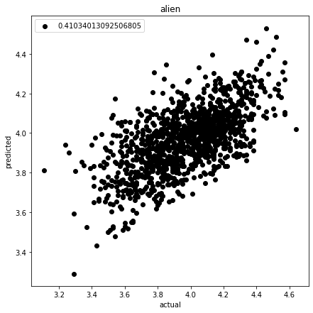

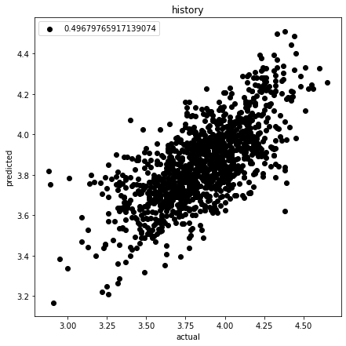

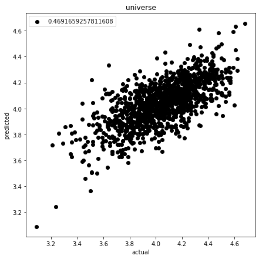

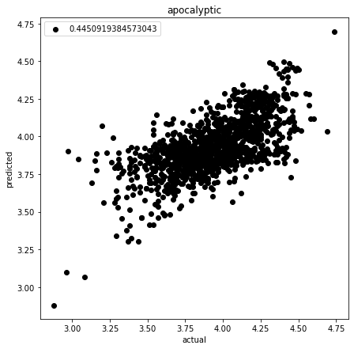

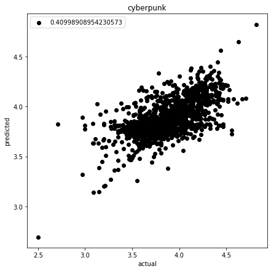

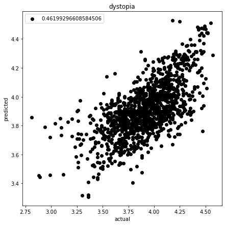

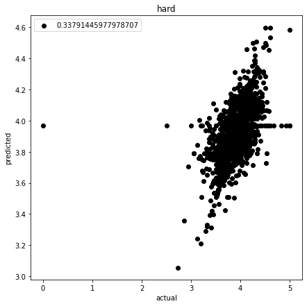

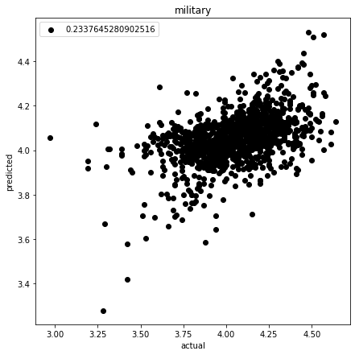

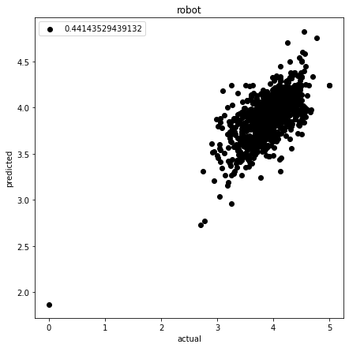

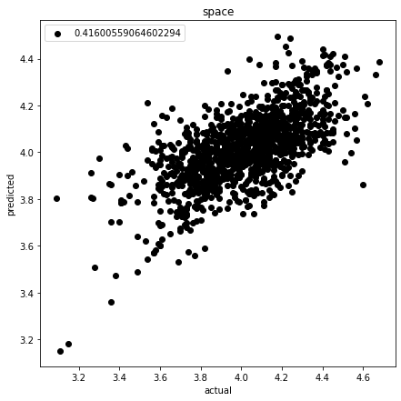

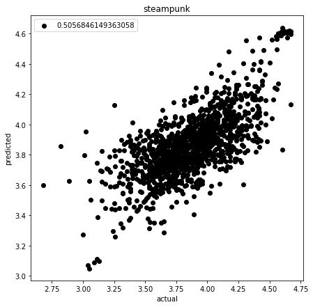

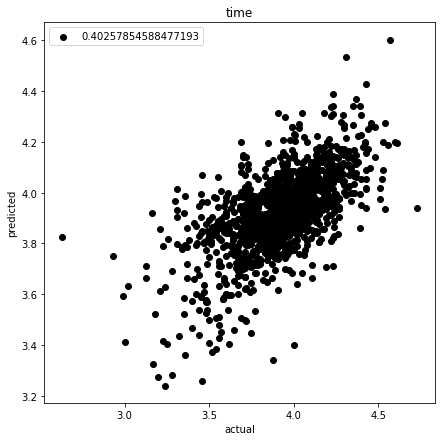

```python
models = {}
for key in dataset:
    fig, ax = plt.subplots(figsize=(7,7))
    X = dataset[key].drop('Rating_score', axis=1)
    y = dataset[key]['Rating_score']
    models[key] = linear_model.LinearRegression().fit(X, y)
    prediction = models[key].predict(X)
    plt.scatter(y, prediction, color="black")
    ax.set_title(key)
    ax.set_xlabel('actual')
    ax.set_ylabel('predicted')
    ax.legend([models[key].score(X, y)])
```

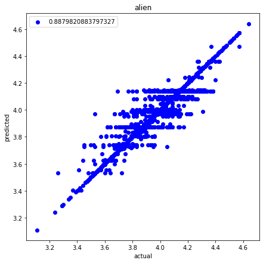

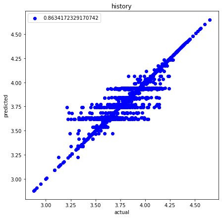

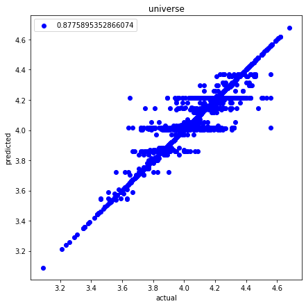

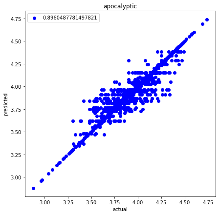

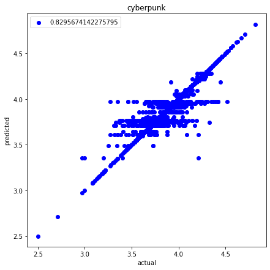

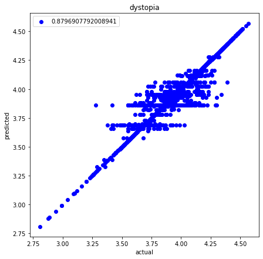

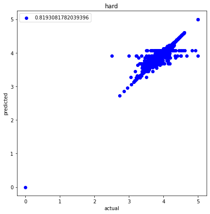

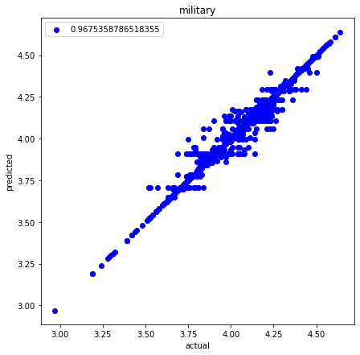

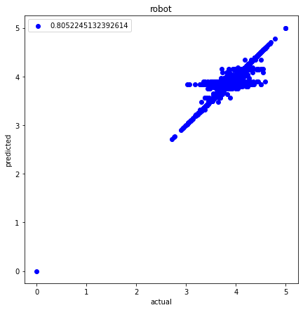

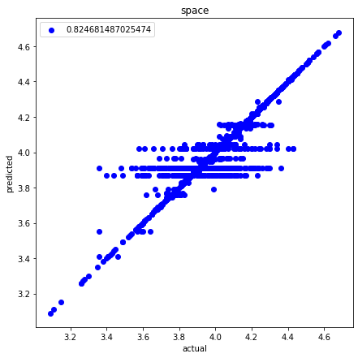

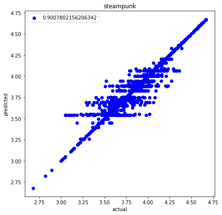

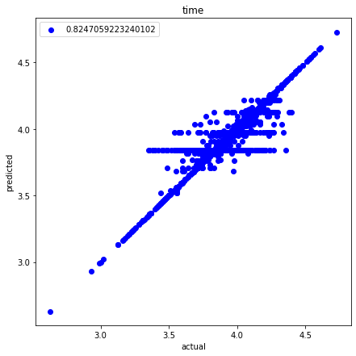

```python
trees = {}
for key in dataset:
    fig, ax = plt.subplots(figsize=(7,7))
    X = dataset[key].drop('Rating_score', axis=1)
    y = dataset[key]['Rating_score']
    trees[key] = DecisionTreeRegressor(random_state=0, max_depth=15).fit(X, y)
    prediction = trees[key].predict(X)
    plt.scatter(y, prediction, color="blue")
    ax.set_title(key)
    ax.set_xlabel('actual')
    ax.set_ylabel('predicted')
    ax.legend([trees[key].score(X, y)])
```

The decision tree regression model performed above my expectations. This may be due to overfitting but I still think it's impressive. With a full depth tree, we may get even better performance although most likely due to overfitting.